# An introduction to ‘ascend’ (Analysis of Single Cell Expression, Normalisation and Differential expression)

Anne Senabouth

2018-08-08

## 1. Introduction

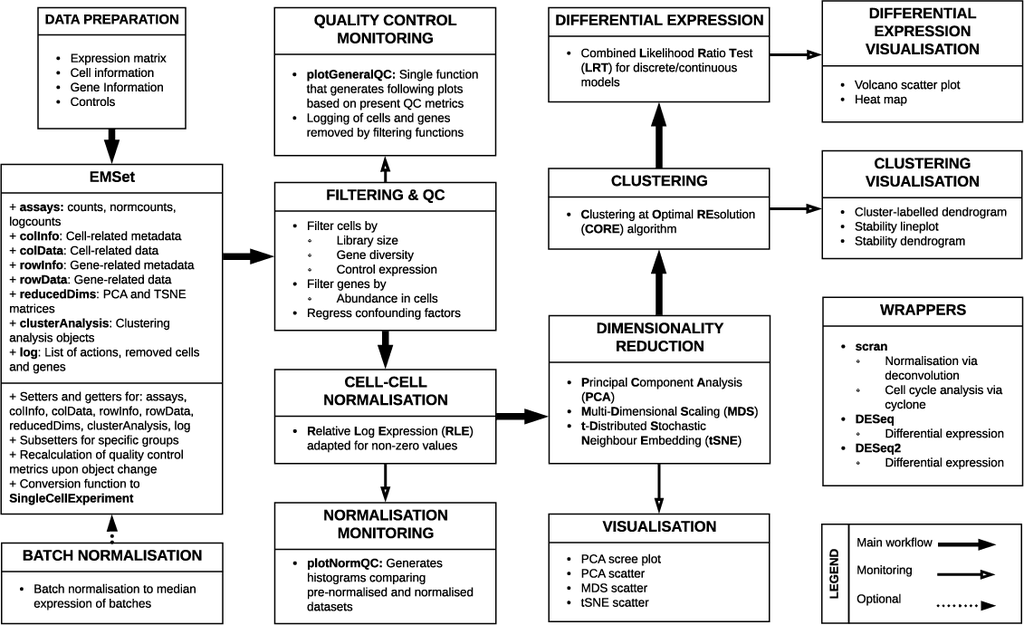

The `ascend` R package provides simple, robust tools for the processing and analysis of data generated by single cell RNA sequencing (scRNA-seq). Summarized in Figure 1, the following stages of scRNA-seq analysis workflows can be performed with `ascend`:

1. Quality control
2. Normalisation
- Between batches
- Within batches
- Between cells
3. Dimensionality reduction
4. Clustering
5. Differential expression

This vignette provides general overview of the `ascend` R package.

Other vignettes cover the following topics:

1. Installation of `ascend` and package dependancies
2. Analysis of retina ganglion cells with `ascend`
3. `ascend` tips and tricks

## 2. Preparing data for use with ‘ascend’

The main source of input is an expression matrix, or a gene-barcode matrix containing transcript counts. Columns represent individual cells, while rows represent genes. Expression matrices are usually the endpoint of scRNA-seq processing pipelines. Data generated by Chromium, DropSeq and inDrop have been tested with this package.

`ascend` is able to use any row and column names in the expression matrix, provided they abide by the following criteria:

1. Names should not repeat. If you have a list with repeats, you can make the names unique by using R’s ‘make.unique’ function.
2. You should be able to identify which genes you would like to select as controls. This is why gene names are preferred.

It is beneficial to prepare cell and gene information to accompany the expression matrix.

Cell information should be loaded into a data frame containing cell identifiers in the first column (cell_barcode), the name of the batch the cell was sequenced in (batch) in the second column, and additional information such as experimental conditions in subsequent columns.

This data frame should be structured as follows:

```r
knitr::kable(data.table::data.table(
  cell_barcode = c("Cell1-1", "Cell2-1", "...", "...", "Cellx-x"),
  batch = c("1", "1", "...", "...", "x")))
```

| cell_barcode | batch |
| --- | --- |
| Cell1-1 | 1 |
| Cell2-1 | 1 |
| … | … |
| … | … |
| Cellx-x | x |

`ascend` will prepare this data frame for you if none is supplied, but will assume all cells belong to a single batch.

Gene information should be loaded into a dataframe containing the gene identifiers used in the expression matrix in the first column, followed by other information. If you need to access other packages that use different gene identifiers (eg. ENSEMBL gene identifiers for cyclone), you can store these identifiers in the data frame and switch the dataset to that set of identifiers using the `convertGeneID` function.

This data frame should be structured as follows:

```r
knitr::kable(data.table::data.table(
  gene_identifier1 = c("GENE1", "GENE2", "...", "...", "GENEX"),
  gene_identifier2 = c("IDENTIFIER1", "IDENTIFIER2", "...", "...",
                                      "IDENTIFIERX")))
```

| gene_identifier1 | gene_identifier2 |
| --- | --- |
| GENE1 | IDENTIFIER1 |
| GENE2 | IDENTIFIER2 |
| … | … |
| … | … |
| GENEX | IDENTIFIERX |

`ascend` will also prepare this data frame for you if none is supplied, but it will only contain the gene identifiers used in the expression matrix.

## 2.1 Controls

You may define genes as controls. It is required if you would like to use `ascend`’s filtering functions. Controls are usually mitochondrial and ribosomal genes, but can also include spike-ins if they were included in the study.

Controls should be organised into groups of control types and in a named list, and the genes must be present in the expression matrix.

```r
# Example controls
controls <- list(Mt = grep("^Mt-", rownames(expression_matrix), ignore.case = TRUE)
                 Rb = grep("^Rps|^Rpl", rownames(expression_matrix), ignore.case = TRUE)
```

## 3. The Expression and Metadata Set (EMSet)

The core of the `ascend` R package is the Expression and Metadata Set (EMSet). This object stores user-supplied data in the form of a gene-cell expression matrix generated by any scRNA-seq platform, in addition to metadata such as cell- or gene-related information. Information generated by `ascend`’s analytical functions are stored in the EMSet and are accessed by downstream functions. Operations are logged within the object and users may review quality control metrics that are updated every time a change is made to the count matrix.

The EMSet extends the SingleCellExperiment superclass from Bioconductor ensuring all layers of the object remain synchronized and users have access to specialized methods for data access. This also enables integration into other single cell analytical workflows; an EMSet can be created from a SingleCellExperiment object, and an EMSet can be converted into a SingleCellExperiment. Convenience functions are supplied to ensure all information stored in an EMSet are preserved upon conversion.

### 3.2 Creating an EMSet

An EMSet can be created with the `newEMSet` function. As the EMSet is built off the SingleCellExperiment class, users may load assays that are stored in a pre- existing SingleCellExperiment object into this function.

```r
# Creating an EMSet from scratch
em_set <- newEMSet(assays = list(counts = expression_matrix),
                   colInfo = col_info_data_frame,
                   rowInfo = row_info_data_frame,
                   controls = control_list)

# Loading an EMSet from a SingleCellExperiment
em_set <- newEMSet(SingleCellExperiment,
                   colInfo = col_info_data_frame,
                   rowInfo = row_info_data_frame,
                   controls = control_list)
```

Refer to the Analysis of retina ganglion cells with ascend vignette for more information on how to prepare and load data into an EMSet.

### 3.3 Manipulating an EMSet

An EMSet is organised as layers of information accessible via functions. These functions can be used to get and set elements of an EMSet.

```r
# Get assays
count_matrix <- counts(EMSet)
norm_matrix <- normcounts(EMSet)
logcounts_matrix <- logcounts(EMSet)

# Set assays
counts(EMSet) <- count_matrix
normcounts(EMSet) <- norm_matrix
logcounts(EMSet) <- logcounts_matrix

# Get gene and cell information
col_info <- colInfo(EMSet)
col_data <- colData(EMSet)
row_info <- rowInfo(EMSet)
row_data <- rowData(EMSet)

# Set gene and cell information
colInfo(EMSet) <- col_info
colData(EMSet) <- col_data
rowInfo(EMSet) <- row_info
rowData(EMSet) <- row_data

# Get reduced dimensionality data
tsne_matrix <- reducedDim(EMSet, "TSNE")
pca_matrix <- reducedDim(EMSet, "PCA")

# Get cluster analysis
clusterAnalysis <- clusterAnalysis(EMSet)

# Get progress log
progressLog <- progressLog(EMSet)
```

The EMSet can also be treated as as a data frame through the use of row/column accessors.

```r
# Reduce EMSet to first ten cells and genes
tiny_EMSet <- EMSet[1:10,1:10]

# Review content in smaller dataset
print(counts(tiny_EMSet))
```

```
#>               CACACAATCTTCCTTC-1 ATGAGGGGTCCATGAT-1 TGGCTGGGTTCGAATC-1
#> FO538757.1                     0                  1                  1
#> AP006222.2                     0                  1                  0
#> RP4-669L17.10                  0                  0                  0
#> RP11-206L10.9                  0                  0                  0
#> LINC00115                      0                  0                  0
#> RP11-54O7.1                    0                  0                  0
#> RP11-54O7.2                    0                  0                  0
#> RP11-54O7.3                    0                  0                  0
#> SAMD11                         0                  4                  1
#> NOC2L                          0                  0                  1
#>               CCATGTCCAACTGCGC-1 ACGGCCACACCAGCAC-1 ACTATCTGTTAAAGTG-1
#> FO538757.1                     0                  0                  0
#> AP006222.2                     1                  0                  0
#> RP4-669L17.10                  0                  0                  0
#> RP11-206L10.9                  0                  0                  0
#> LINC00115                      0                  0                  0
#> RP11-54O7.1                    0                  0                  0
#> RP11-54O7.2                    0                  0                  0
#> RP11-54O7.3                    0                  0                  0
#> SAMD11                         0                  0                  0
#> NOC2L                          0                  0                  0
#>               TCTATTGCAAACCCAT-1 TGATTTCTCTCCGGTT-1 GCGCGATTCGTTGACA-1
#> FO538757.1                     0                  2                  0
#> AP006222.2                     0                  1                  0
#> RP4-669L17.10                  0                  0                  0
#> RP11-206L10.9                  0                  0                  0
#> LINC00115                      0                  0                  0
#> RP11-54O7.1                    0                  0                  0
#> RP11-54O7.2                    0                  0                  0
#> RP11-54O7.3                    0                  0                  0
#> SAMD11                         0                  2                  2
#> NOC2L                          0                  0                  0
#>               TCGTACCCAGTTCATG-1
#> FO538757.1                     0
#> AP006222.2                     0
#> RP4-669L17.10                  0
#> RP11-206L10.9                  0
#> LINC00115                      0
#> RP11-54O7.1                    0
#> RP11-54O7.2                    0
#> RP11-54O7.3                    0
#> SAMD11                         0
#> NOC2L                          1
```

```r
print(colInfo(tiny_EMSet))
```

```
#> DataFrame with 10 rows and 3 columns
#>                          cell_barcode     batch   cluster
#>                           <character> <numeric> <integer>
#> CACACAATCTTCCTTC-1 CACACAATCTTCCTTC-1         1         1
#> ATGAGGGGTCCATGAT-1 ATGAGGGGTCCATGAT-1         1         2
#> TGGCTGGGTTCGAATC-1 TGGCTGGGTTCGAATC-1         1         1
#> CCATGTCCAACTGCGC-1 CCATGTCCAACTGCGC-1         1         2
#> ACGGCCACACCAGCAC-1 ACGGCCACACCAGCAC-1         1         1
#> ACTATCTGTTAAAGTG-1 ACTATCTGTTAAAGTG-1         1         1
#> TCTATTGCAAACCCAT-1 TCTATTGCAAACCCAT-1         1         2
#> TGATTTCTCTCCGGTT-1 TGATTTCTCTCCGGTT-1         1         2
#> GCGCGATTCGTTGACA-1 GCGCGATTCGTTGACA-1         1         1
#> TCGTACCCAGTTCATG-1 TCGTACCCAGTTCATG-1         1         1
```

```r
print(rowInfo(tiny_EMSet))
```

```
#> DataFrame with 10 rows and 3 columns
#>                     gene_id ensembl_gene_id control_group
#>                 <character>     <character>   <character>
#> FO538757.1       FO538757.1 ENSG00000279457            NA
#> AP006222.2       AP006222.2 ENSG00000228463            NA
#> RP4-669L17.10 RP4-669L17.10 ENSG00000237094            NA
#> RP11-206L10.9 RP11-206L10.9 ENSG00000237491            NA
#> LINC00115         LINC00115 ENSG00000225880            NA
#> RP11-54O7.1     RP11-54O7.1 ENSG00000230699            NA
#> RP11-54O7.2     RP11-54O7.2 ENSG00000241180            NA
#> RP11-54O7.3     RP11-54O7.3 ENSG00000223764            NA
#> SAMD11               SAMD11 ENSG00000187634            NA
#> NOC2L                 NOC2L ENSG00000188976            NA
```

The subgroups within the EMSet can also be subsetted from the EMSet with the `subsetCondition` function. The condition needs to be set in the colInfo slot.

```r
# Subset batch 1 from the combined EMSet
Batch1_EMSet <- subsetCondition(EMSet, by = "batch", conditions = list(batch = c(1)))
```

## 4. Visualising with ‘ascend’

Most plots in `ascend` are generated via the ggplot2 package. These plots can be modified further by the user with ggplot2 functions, as described in the [package documentation](http://ggplot2.tidyverse.org/reference/).

[output not shown]

### 4.1 Example plots - t-SNE

t-SNE plots are a popular way to visualise scRNA-seq data. As t-SNE plots are best used in conjunction with information generated from other analysis, the plotTSNE function in `ascend` can use information stored in the colInfo slot label cells.

Before we can generate a t-SNE plot, we need to reduce the data with the method. We will supply the `runTSNE` function with a seed value as we may want to replicate this analysis.

```r
EMSet <- runTSNE(EMSet, seed = 1)
```

```
#> [1] "Running Rtsne..."
#> [1] "Rtsne complete! Returning matrix..."
```

We can then use `plotTSNE` to visualise the clusters we identified via the runCORE function.

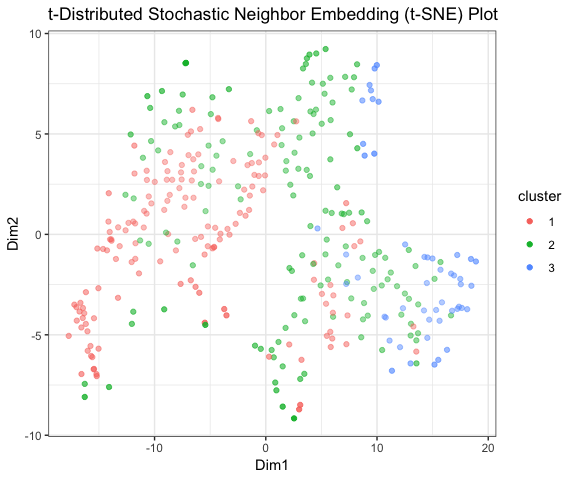

```r
tsne_plot <- plotTSNE(EMSet, group = "cluster")
tsne_plot
```

As the t-SNE plot was generated via ggplot2, we can use ggplot2 functions to modify the graph. In this case, we want to change the colours of the clusters.

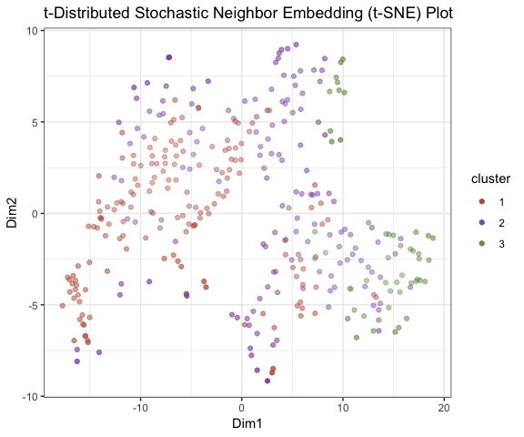

```r
library(ggplot2)
tsne_plot <- tsne_plot + scale_color_manual(values=c("#bb5f4c",
                                                     "#8e5db0",
                                                     "#729b57"))
tsne_plot
```

## 5. Using ‘ascend’ with other packages

Many Bioconductor packages that are dedicated to scRNA-seq analysis use classes that are related to the SingleCellExperiment class. As the EMSet contains additional information, we have provided a conversion function `EMSet2SCE`that preserves this information within a SingleCellExperiment object. The resulting SingleCellExperiment object can then be reverted to the EMSet using the `SCE2EMSet` function.

```r
# Convert to SingleCellExperiment
SingleCellExperiment <- EMSet2SCE(EMSet)

# Revert to SingleCellExperiment
EMSet <- SCE2EMSet(SingleCellExperiment)
```

## 5.1 Third-party wrappers

We have created wrappers for specific tasks in `scran`, `DESeq` and `DESeq2`. They provide alternatives for specific stages in the `ascend` workflow and provide more in-depth analysis.

### 5.1.1 scran

#### 5.1.1.1 scran normalisation by deconvolution

This method is regarded as an advanced normalisation method for scRNA-seq data. This method groups the cells into pools for size factor calculation before they are applied to the dataset.

```r
scran_normalised <- scranNormalise(RawSet, quickCluster = FALSE, min.mean = 1e-05)
```

```
#> [1] "386 cells detected. Running computeSumFactors with preset sizes of 40, 60, 80, 100..."
#> [1] "scran's computeSumFactors complete. Adjusting zero sum factors..."
#> [1] "Running scater's normalize method..."
#> [1] "Normalisation complete. Converting SingleCellExperiment back to EMSet..."
```

#### 5.1.1.2 scran cell cycle

As the *Homo sapiens* training dataset that comes with scran uses ENSEMBL gene identifiers, we need to convert the EMSet’s gene identifiers to them. Fortunately, we have retained these in rowInfo under the “ensembl_gene_id” column.

```r
# Convert identifiers to ENSEMBL gene identifiers
ensembl_set <- convertGeneID(RawSet, new.annotation = "ensembl_gene_id")

# Load training data from scran
training_data <- readRDS(system.file("exdata", "human_cycle_markers.rds",
                                     package = "scran"))

# Run cell cycle
scran_cellcycle <- scranCellCycle(ensembl_set, training_set = training_data)

# Show cell cycle results
colInfo(scran_cellcycle)
```

### 5.1.2 DESeq

We have included wrappers for DESeq as the differential expression analysis for our earlier scRNA-seq datasets were preformed with this package. We found the results were comparable with other methods. Our optimisations have decreased the runtime of this package as well.

```r
cluster2_vs_others <- runDESeq(EMSet, group = "cluster",
                               condition.a = 2, condition.b = c(1, 3),
                               ngenes = 1500)
```

### 5.1.3 DESeq2

We have also included wrappers for DESeq2 on request. This package requires substantially more time to run.

```r
cluster1_vs_others <- runDESeq2(EMSet, group = "cluster",
                               condition.a = 1, condition.b = c(2, 3),
                               ngenes = 1500)
```